# Analyse descriptive de 3 espèces d’iris en Gaspésie (Canada)

Engels Guyliann

2018-09-04

```r
# Le premier chunk porte le nom de "R setups", il doit contenir :
# l'ensemble des outils nécéssaires à l'analyse des données (packages,...)
SciViews::R
library(viridis)
library(ggmap)
```

# 1 Introduction

L’étude porte sur les variations morphologiques de trois espèces d’iris que sont *Iris setosa* Pall. ex Link (1820) , *Iris versicolor* L. (1753), *Iris virginica* L.. Ces espèces appartiennent à la famille des iridaceae. Ces trois espèces se développent dans des milieux humides.

# 2 Matériels et méthodes

Edgar Anderson (1935) récolte les trois espèces d’iris en Gaspésie (Québec, Canada). La péninsule de gaspésie est entourée par l’estuaire du fleuve Saint-Laurent, le golfe du Saint-Laurent et de la baie des chaleurs (carte réalisé avec le package ggmap (Kahle and Wickham 2013))

[figure not shown]

```r
#48° 40′ 00″ nord, 65° 40′ 00″ ouest
map <- get_googlemap(center = c(lon = -65.833333, lat = 48.666667 ), zoom = 3, maptype = "satellite")
ggmap(map) +
  geom_point(mapping = aes(x = -65.833333, y  = 48.666667), color = "red")
```

Cinquantes individus par espèces sont prélevés afin de réaliser la biométire des pétales et sépales. Pour ce faire, la longueur et la largeur des pétales et sépales sont mesurées en centimètre.

L’analyse des données et la rédaction de ce rapport sont réalisé avec R version 3.4.4 et R Studio version 1.1.456.

# 3 Résultat

```r
# Importation des données
iris <- read("iris", package = "datasets")
```

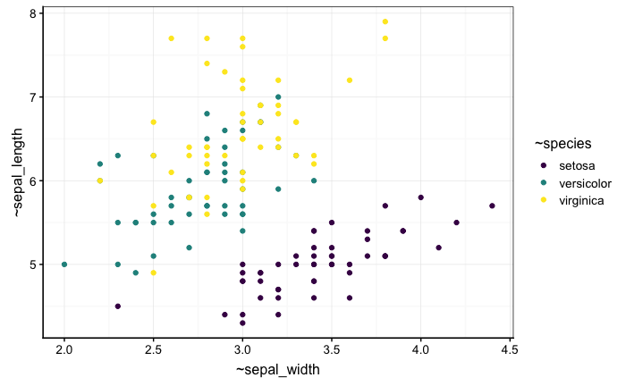

```r
chart(iris, sepal_length ~ sepal_width %col=% species) +
  geom_point() +
  scale_color_viridis(discrete = TRUE)
```

La différence morphologique des sépales permet d’isoler *I.setosa* des deux autres espèces d’iris.

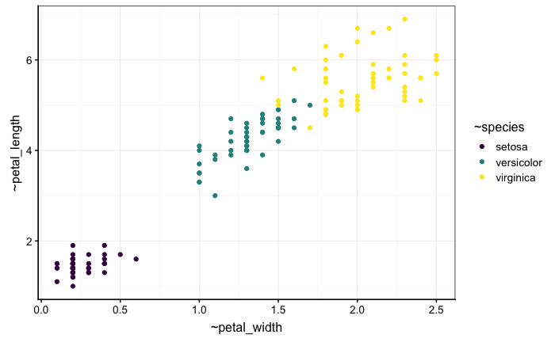

```r
chart(iris, petal_length ~ petal_width %col=% species) +
  geom_point() +
  scale_color_viridis(discrete = TRUE)
```

Comme le montre la figure ci-dessus, *I. setosa* a des pétales plus courtes et plus fines que d’*I. versicolor* et d’*I. virginica*.

La différence morphologique des pétales permet d’une part d’isoler à nouveau *I. setosa* des deux autres espèces. Elle permet également d’obtenir une meilleure distinction entre *I.versicolor* et *I. virginica*.

# 4 Discussion

# 5 Conclusion

la biométrie des pétales et des sépales sont de bonnes variables afin de différencier *I. setosa* de *I. versicolor* et *I. virginica*.

# 6 Bibliographie

Anderson, Edgar. 1935. “The Irises of the Gaspe Peninsula.” *Bulletin of the American Iris Society* 59: 2–5.

———. 1936. “The Species Problem in Iris.” *Annals of the Missouri Botanical Garden* 23 (3). Missouri Botanical Garden Press: 457–509. doi:10.2307/2394164.

Kahle, David, and Hadley Wickham. 2013. “Ggmap: Spatial Visualization with Ggplot2.” *The R Journal* 5 (1): 144–61. http://journal.r-project.org/archive/2013-1/kahle-wickham.pdf.